[output not shown]

# Introducción

En esta tarea se analizarán cuatro series de tiempo incluidas en R.

# Desarrollo

## Carga de las series

Las series utilizadas están disponibles en R, por lo que no es necesario descargarlas desde internet.

```r
# Se reúnen las cuatro series en una lista para analizarlas de la misma forma.
# Cada serie se convierte en un vector numérico y conserva únicamente sus valores.
series_A <- list(
  `Nivel del lago Hurón` = as.numeric(LakeHuron),        # Serie anual con 98 datos.
  `Temperatura en Nottingham` = as.numeric(nottem),     # Serie mensual con 240 datos.
  `Población de Australia` = as.numeric(austres),       # Serie trimestral con 89 datos.
  `Muertes accidentales` = as.numeric(USAccDeaths)      # Serie mensual con 72 datos.
)
```

## Gráficas de las series y sus ACF

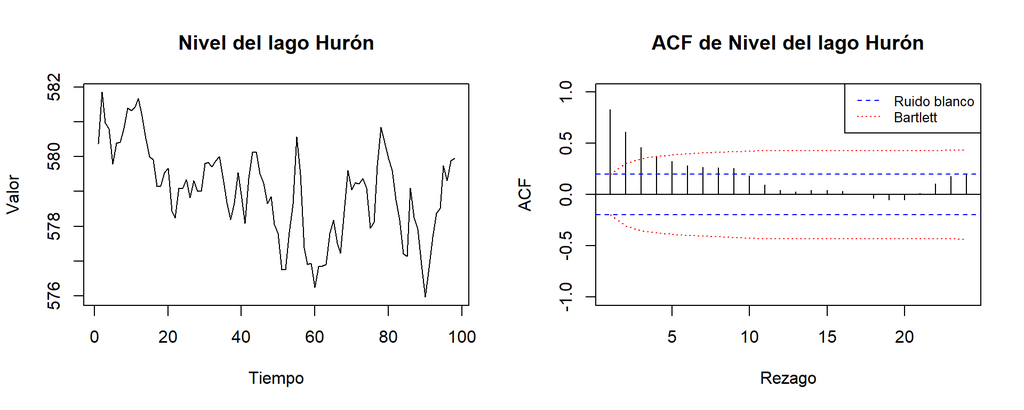

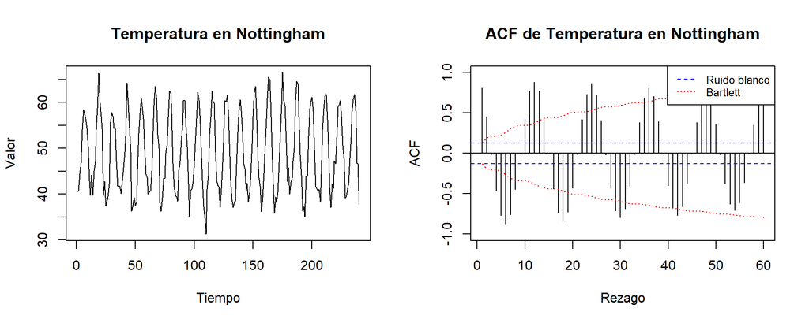

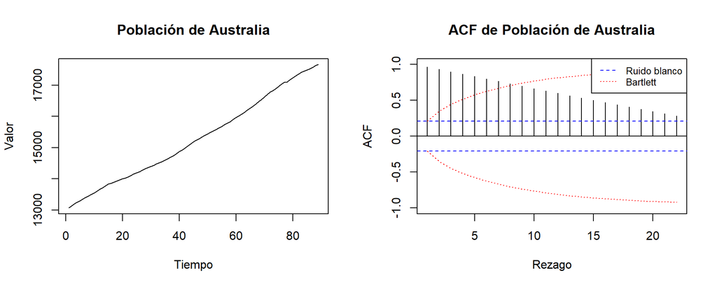

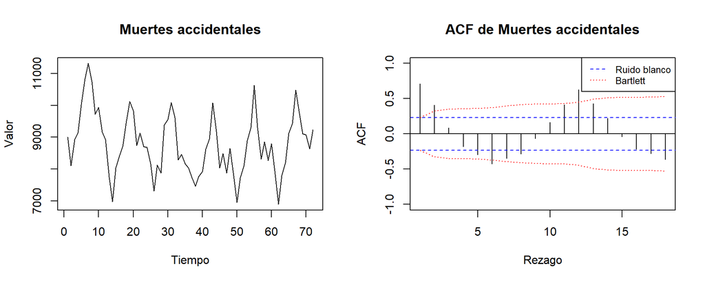

```r
# Se divide el espacio gráfico en dos partes para comparar cada serie con su ACF.
par(mfrow = c(1, 2))

# Se recorre la lista y se trabaja con una serie a la vez.
for (nombre in names(series_A)) {
  # A la izquierda se dibuja la evolución de los valores en el tiempo.
  plot(series_A[[nombre]], type = "l", main = nombre,
       xlab = "Tiempo", ylab = "Valor")

  # Se usa aproximadamente la cuarta parte de los datos como número de rezagos.
  n <- length(series_A[[nombre]])
  m <- floor(n / 4)

  # Se calcula la ACF hasta el rezago m sin dibujarla todavía.
  resultado_acf <- acf(series_A[[nombre]], lag.max = m, plot = FALSE)
  rezagos <- as.numeric(resultado_acf$lag)[-1]
  correlaciones <- as.numeric(resultado_acf$acf)[-1]

  # La banda azul supone que la serie es ruido blanco.
  banda_blanca <- qnorm(0.975) / sqrt(n)

  # La banda roja de Bartlett cambia según las correlaciones anteriores.
  sumas_previas <- c(0, cumsum(correlaciones[-length(correlaciones)]^2))
  banda_bartlett <- qnorm(0.975) * sqrt((1 + 2 * sumas_previas) / n)

  # A la derecha se dibuja la ACF y se añaden ambas bandas de confianza.
  plot(rezagos, correlaciones, type = "h", ylim = c(-1, 1),
       main = paste("ACF de", nombre), xlab = "Rezago", ylab = "ACF")
  abline(h = 0)
  abline(h = c(-banda_blanca, banda_blanca), col = "blue", lty = 2)
  lines(rezagos, banda_bartlett, col = "red", lty = 3)
  lines(rezagos, -banda_bartlett, col = "red", lty = 3)
  legend("topright", c("Ruido blanco", "Bartlett"),
         col = c("blue", "red"), lty = c(2, 3), cex = 0.8)
}
```

## Valores de autocorrelación seleccionados

El período estacional es 1 para la serie anual, 12 para las series mensuales y 4 para la serie trimestral.

```r
# Se guarda el período estacional que corresponde a cada serie.
periodos <- c(
  `Nivel del lago Hurón` = 1,
  `Temperatura en Nottingham` = 12,
  `Población de Australia` = 4,
  `Muertes accidentales` = 12
)

# Se crea una tabla vacía para guardar los resultados de cada serie.
tabla_acf <- data.frame()

# Se calcula la ACF y se extraen los valores de los rezagos 1, s y 2s.
for (nombre in names(series_A)) {
  serie <- series_A[[nombre]]
  s <- periodos[nombre]
  r <- as.numeric(acf(serie, lag.max = 2 * s, plot = FALSE)$acf)

  tabla_acf <- rbind(
    tabla_acf,
    data.frame(
      Serie = nombre,
      s = s,
      r1 = r[2],
      rs = r[s + 1],
      r2s = r[2 * s + 1]
    )
  )
}

# Se presenta la tabla con tres cifras decimales.
knitr::kable(tabla_acf, digits = 3, row.names = FALSE)
```

| Serie | s | r1 | rs | r2s |
| --- | --- | --- | --- | --- |
| Nivel del lago Hurón | 1 | 0.832 | 0.832 | 0.610 |
| Temperatura en Nottingham | 12 | 0.808 | 0.884 | 0.866 |
| Población de Australia | 4 | 0.967 | 0.866 | 0.732 |
| Muertes accidentales | 12 | 0.707 | 0.629 | 0.450 |

## Prueba de Ljung–Box

La prueba de Ljung–Box permite evaluar conjuntamente las autocorrelaciones desde el rezago 1 hasta el rezago 24.

### Hipótesis de la prueba

**Hipótesis nula:**

$$H_0: \rho_1 = \rho_2 = \cdots = \rho_{24} = 0$$

La serie no presenta autocorrelación en los primeros 24 rezagos y se comporta como ruido blanco.

**Hipótesis alternativa:**

$$H_1: \rho_k \neq 0 \quad \text{para al menos un } k \in \{1,\ldots,24\}$$

La serie presenta autocorrelación en al menos uno de los primeros 24 rezagos.

Se utiliza un nivel de significancia de $\alpha=0.05$. Si el valor p es menor que 0.05, se rechaza $H_0$; en caso contrario, no se rechaza $H_0$.

```r
# Se crea una tabla vacía para guardar el resultado de cada prueba.
tabla_ljung <- data.frame()

# Se aplica la prueba de Ljung-Box con 24 rezagos a cada serie.
for (nombre in names(series_A)) {
  prueba <- Box.test(series_A[[nombre]], lag = 24, type = "Ljung-Box")

  # Se guardan el estadístico Q y el valor p obtenidos para la serie.
  tabla_ljung <- rbind(
    tabla_ljung,
    data.frame(
      Serie = nombre,
      Q = as.numeric(prueba$statistic),
      p = format.pval(prueba$p.value, digits = 3, eps = 0.001)
    )
  )
}

# Se presenta la tabla con el estadístico Q redondeado a tres cifras.
knitr::kable(tabla_ljung, digits = 3, row.names = FALSE,
             col.names = c("Serie", "Q", "Valor p"))
```

| Serie | Q | Valor p |
| --- | --- | --- |
| Nivel del lago Hurón | 203.237 | <0.001 |
| Temperatura en Nottingham | 2342.383 | <0.001 |
| Población de Australia | 953.448 | <0.001 |
| Muertes accidentales | 237.019 | <0.001 |

La hipótesis nula afirma que las autocorrelaciones de los primeros 24 rezagos son iguales a cero. En las cuatro series el valor p es menor que 0.001. Por lo tanto, con un nivel de significancia del 5 %, se rechaza la hipótesis nula en todos los casos. Esto indica que las cuatro series presentan dependencia temporal y no se comportan como ruido blanco.

## Clasificación de las series

[output not shown]

## Series para las rutas 1 y 2

En esta sección se preparan las series que se utilizarán en las dos rutas de análisis.

```r
# La ruta 1 utiliza la temperatura mensual de Nottingham.
y_ruta1 <- as.numeric(nottem)
s1 <- 12

# La ruta 2 utiliza el consumo trimestral de gas del Reino Unido.
y_ruta2 <- as.numeric(UKgas)
s2 <- 4

# Se comprueba la cantidad de observaciones que tiene cada serie.
c(T1 = length(y_ruta1), T2 = length(y_ruta2))
```

```
##  T1  T2
## 240 108
```

La primera serie tiene 240 observaciones y un período estacional de 12 meses. La segunda tiene 108 observaciones y un período estacional de 4 trimestres.

### Gráficas y correlogramas de las dos series

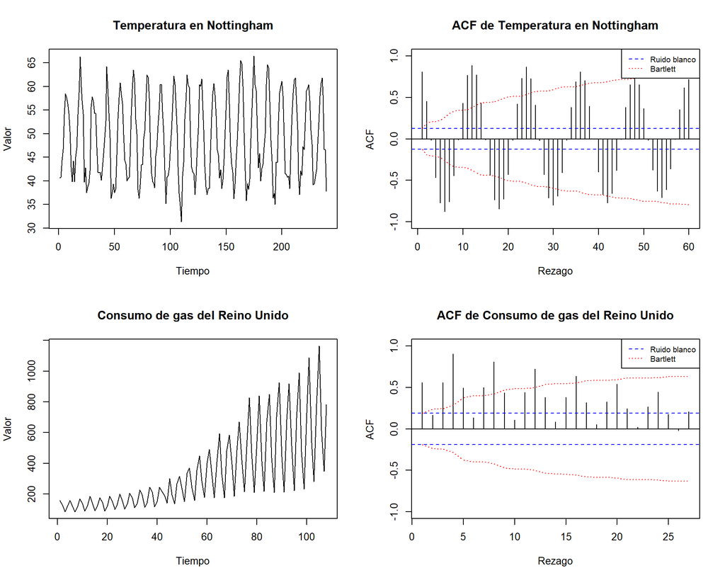

```r
# Se reúnen las dos series para graficarlas con el mismo procedimiento.
rutas <- list(
  `Temperatura en Nottingham` = y_ruta1,
  `Consumo de gas del Reino Unido` = y_ruta2
)

# Cada fila mostrará una serie a la izquierda y su correlograma a la derecha.
par(mfrow = c(2, 2))

# Se recorre la lista y se trabaja con una serie a la vez.
for (nombre in names(rutas)) {
  serie <- rutas[[nombre]]

  # Primero se dibuja la evolución de la serie en el tiempo.
  plot(serie, type = "l", main = nombre,
       xlab = "Tiempo", ylab = "Valor")

  # Se calcula la ACF usando aproximadamente T/4 rezagos.
  n <- length(serie)
  m <- floor(n / 4)
  resultado_acf <- acf(serie, lag.max = m, plot = FALSE)
  rezagos <- as.numeric(resultado_acf$lag)[-1]
  correlaciones <- as.numeric(resultado_acf$acf)[-1]

  # Se calculan la banda de ruido blanco y la banda de Bartlett.
  banda_blanca <- qnorm(0.975) / sqrt(n)
  sumas_previas <- c(0, cumsum(correlaciones[-length(correlaciones)]^2))
  banda_bartlett <- qnorm(0.975) * sqrt((1 + 2 * sumas_previas) / n)

  # Luego se dibuja el correlograma con las dos bandas de confianza.
  plot(rezagos, correlaciones, type = "h", ylim = c(-1, 1),
       main = paste("ACF de", nombre), xlab = "Rezago", ylab = "ACF")
  abline(h = 0)
  abline(h = c(-banda_blanca, banda_blanca), col = "blue", lty = 2)
  lines(rezagos, banda_bartlett, col = "red", lty = 3)
  lines(rezagos, -banda_bartlett, col = "red", lty = 3)
  legend("topright", c("Ruido blanco", "Bartlett"),
         col = c("blue", "red"), lty = c(2, 3), cex = 0.8)
}
```

### Componentes observados en las series

En cada celda se puede indicar **Se observa** o **No se observa**, de acuerdo con el comportamiento mostrado en las gráficas.

[output not shown]

## Ruta 2: nivel y amplitud por año

Para cada año, el **nivel medio** es el promedio de sus cuatro observaciones trimestrales. La **amplitud estacional** es la diferencia entre el trimestre con mayor consumo y el trimestre con menor consumo del mismo año.

```r
# La función matrix organiza el vector y_ruta2 en una tabla.
# ncol = s2 crea cuatro columnas, porque cada año tiene cuatro trimestres.
# byrow = TRUE coloca cada grupo de cuatro datos consecutivos en una misma fila.
datos_anuales <- matrix(y_ruta2, ncol = s2, byrow = TRUE)

# Cada fila de datos_anuales representa un año entre 1960 y 1986.
anios <- 1960:1986

# rowMeans calcula el promedio de cada fila.
# El resultado es un vector con un nivel medio para cada año.
nivel_medio <- rowMeans(datos_anuales)

# apply recorre la matriz por filas porque MARGIN = 1.
# Para cada año, max obtiene el valor mayor y min obtiene el menor.
# La resta entre ambos valores produce la amplitud estacional anual.
amplitud_estacional <- apply(
  datos_anuales,
  MARGIN = 1,
  FUN = function(valores) max(valores) - min(valores)
)

# data.frame reúne los tres vectores en columnas de una sola tabla.
# Cada fila contiene el año, su nivel medio y su amplitud estacional.
resumen_ruta2 <- data.frame(
  Año = anios,
  Nivel_medio = nivel_medio,
  Amplitud_estacional = amplitud_estacional
)

# kable presenta el objeto resumen_ruta2 como una tabla en el informe.
knitr::kable(resumen_ruta2, digits = 3, row.names = FALSE)
```

| Año | Nivel_medio | Amplitud_estacional |
| --- | --- | --- |
| 1960 | 123.675 | 75.3 |
| 1961 | 121.675 | 75.3 |
| 1962 | 130.900 | 80.0 |
| 1963 | 136.100 | 94.4 |
| 1964 | 134.100 | 86.4 |
| 1965 | 142.900 | 86.4 |
| 1966 | 150.100 | 97.6 |
| 1967 | 158.500 | 92.8 |
| 1968 | 170.100 | 112.0 |
| 1969 | 182.900 | 126.4 |
| 1970 | 198.100 | 102.4 |
| 1971 | 225.325 | 164.9 |
| 1972 | 258.950 | 184.1 |
| 1973 | 281.350 | 212.9 |
| 1974 | 329.800 | 270.6 |
| 1975 | 350.200 | 313.8 |
| 1976 | 395.825 | 417.8 |
| 1977 | 413.025 | 397.0 |
| 1978 | 453.850 | 453.1 |
| 1979 | 511.900 | 618.0 |
| 1980 | 535.900 | 622.8 |
| 1981 | 549.100 | 638.8 |
| 1982 | 566.700 | 710.8 |
| 1983 | 587.925 | 693.2 |
| 1984 | 607.550 | 755.7 |
| 1985 | 672.775 | 805.2 |
| 1986 | 726.800 | 816.5 |

### Relación entre la amplitud y el nivel

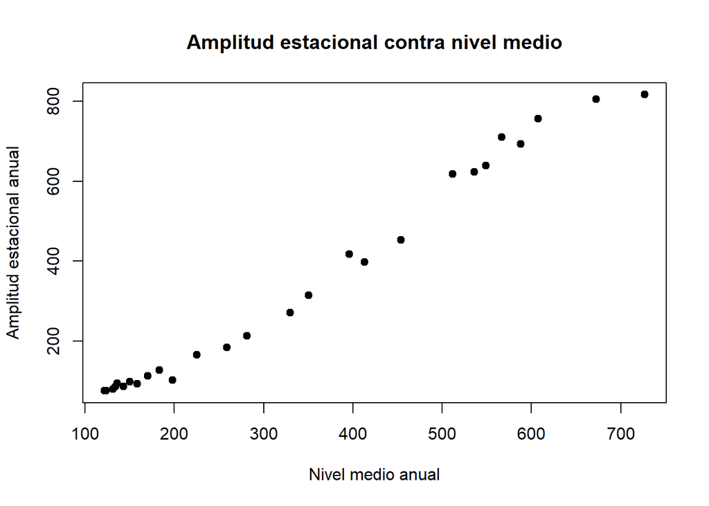

```r
# El símbolo $ selecciona una columna específica de resumen_ruta2.
# plot coloca el nivel medio en el eje horizontal y la amplitud en el vertical.
# Cada punto representa uno de los años de la serie.
plot(
  resumen_ruta2$Nivel_medio,
  resumen_ruta2$Amplitud_estacional,
  main = "Amplitud estacional contra nivel medio",
  xlab = "Nivel medio anual",
  ylab = "Amplitud estacional anual",
  pch = 19
)
```

```r
# cor mide la relación lineal entre las dos columnas.
# El resultado puede variar entre -1 y 1; un valor cercano a 1 indica
# que la amplitud aumenta a medida que aumenta el nivel.
correlacion <- cor(
  resumen_ruta2$Nivel_medio,
  resumen_ruta2$Amplitud_estacional
)

# Se muestra la correlación redondeada a tres cifras decimales.
round(correlacion, 3)
```

```
## [1] 0.992
```

La correlación entre el nivel medio y la amplitud estacional es **0.992**. En el gráfico, la amplitud aumenta claramente cuando aumenta el nivel de la serie. Además, la correlación es positiva y muy cercana a 1. Por estas razones, se concluye que la escala de la ruta 2 es **multiplicativa**. En una escala aditiva, la amplitud permanecería aproximadamente constante aunque cambiara el nivel.

### Correlogramas de las dos rutas

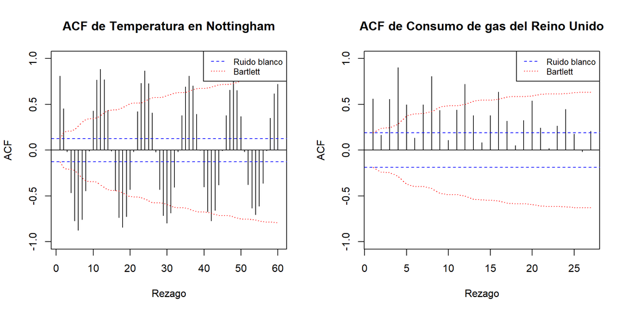

```r
# Este vector guarda el período estacional de cada serie.
# El primer valor corresponde a nottem y el segundo a UKgas.
periodos_rutas <- c(s1, s2)

# par divide la figura en dos columnas para mostrar un correlograma por ruta.
par(mfrow = c(1, 2))

# seq_along produce las posiciones 1 y 2 para recorrer ambas series.
for (i in seq_along(rutas)) {
  # [[i]] extrae la serie situada en la posición i de la lista rutas.
  serie <- rutas[[i]]

  # length cuenta los datos y floor toma la parte entera de T/4.
  T <- length(serie)
  m <- floor(T / 4)

  # acf calcula las autocorrelaciones hasta m, pero no las grafica todavía.
  resultado <- acf(serie, lag.max = m, plot = FALSE)

  # $lag y $acf extraen los rezagos y las autocorrelaciones del resultado.
  # [-1] elimina el rezago 0, cuya autocorrelación siempre es igual a 1.
  rezagos <- as.numeric(resultado$lag)[-1]
  correlaciones <- as.numeric(resultado$acf)[-1]

  # La primera expresión calcula la banda constante de ruido blanco.
  banda_blanca <- qnorm(0.975) / sqrt(T)

  # cumsum acumula los cuadrados de las correlaciones anteriores.
  # Estas sumas permiten que la banda de Bartlett cambie con el rezago.
  sumas_previas <- c(0, cumsum(correlaciones[-length(correlaciones)]^2))
  banda_bartlett <- qnorm(0.975) * sqrt((1 + 2 * sumas_previas) / T)

  # plot dibuja las autocorrelaciones como líneas verticales.
  # names(rutas)[i] toma el nombre de la serie para formar el título.
  plot(rezagos, correlaciones, type = "h", ylim = c(-1, 1),
       main = paste("ACF de", names(rutas)[i]),
       xlab = "Rezago", ylab = "ACF")
  abline(h = 0)

  # Las líneas azules corresponden a la banda de ruido blanco.
  abline(h = c(-banda_blanca, banda_blanca), col = "blue", lty = 2)

  # Las líneas rojas corresponden a los dos límites de Bartlett.
  lines(rezagos, banda_bartlett, col = "red", lty = 3)
  lines(rezagos, -banda_bartlett, col = "red", lty = 3)

  # legend explica el color y el tipo de línea de cada banda.
  legend("topright", c("Ruido blanco", "Bartlett"),
         col = c("blue", "red"), lty = c(2, 3), cex = 0.8)
}
```

La ruta 1 utiliza $m=\lfloor240/4\rfloor=60$ rezagos y la ruta 2 utiliza $m=\lfloor108/4\rfloor=27$.

### Autocorrelaciones en los rezagos estacionales

```r
# Se crea una tabla vacía que recibirá una fila por cada ruta.
tabla_estacional <- data.frame()

# El ciclo recorre las dos series y sus períodos estacionales.
for (i in seq_along(rutas)) {
  serie <- rutas[[i]]
  s <- periodos_rutas[i]

  # Los cuatro rezagos solicitados son s, 2s, 3s y 4s.
  rezagos_estacionales <- c(s, 2 * s, 3 * s, 4 * s)

  # acf calcula hasta 4s, el mayor rezago que se necesita reportar.
  resultado <- acf(serie, lag.max = 4 * s, plot = FALSE)

  # Se suma 1 porque la primera posición del objeto corresponde al rezago 0.
  valores <- as.numeric(resultado$acf)[rezagos_estacionales + 1]

  # rbind añade a la tabla una fila con el nombre y los cuatro resultados.
  tabla_estacional <- rbind(
    tabla_estacional,
    data.frame(
      Serie = names(rutas)[i],
      s = s,
      rs = valores[1],
      r2s = valores[2],
      r3s = valores[3],
      r4s = valores[4]
    )
  )
}

# kable muestra la tabla y redondea las autocorrelaciones a tres decimales.
knitr::kable(tabla_estacional, digits = 3, row.names = FALSE,
             col.names = c("Serie", "s", "r_s", "r_2s", "r_3s", "r_4s"))
```

| Serie | s | r_s | r_2s | r_3s | r_4s |
| --- | --- | --- | --- | --- | --- |
| Temperatura en Nottingham | 12 | 0.884 | 0.866 | 0.81 | 0.762 |
| Consumo de gas del Reino Unido | 4 | 0.902 | 0.806 | 0.72 | 0.633 |

### Interpretación de los picos estacionales

[output not shown]

### Prueba de Ljung–Box para las dos rutas

En cada serie se utiliza $m=4s$. Por ello, la ruta 1 usa 48 rezagos y la ruta 2 usa 16.

**Hipótesis nula:**

$$H_0: \rho_1 = \rho_2 = \cdots = \rho_{4s} = 0$$

La serie no presenta autocorrelación en los primeros $4s$ rezagos.

**Hipótesis alternativa:**

$$H_1: \rho_k \neq 0 \quad \text{para al menos un } k \in \{1,\ldots,4s\}$$

La serie presenta autocorrelación en al menos uno de los primeros $4s$ rezagos.

```r
# Se crea una tabla vacía para almacenar una prueba por cada ruta.
tabla_ljung_rutas <- data.frame()

# El ciclo aplica el mismo procedimiento a las dos series.
for (i in seq_along(rutas)) {
  serie <- rutas[[i]]
  s <- periodos_rutas[i]

  # La cantidad de rezagos de la prueba se obtiene multiplicando 4 por s.
  m_ljung <- 4 * s

  # Box.test aplica la prueba y devuelve, entre otros datos, Q y el valor p.
  prueba <- Box.test(serie, lag = m_ljung, type = "Ljung-Box")

  # rbind agrega los resultados de la serie actual como una nueva fila.
  tabla_ljung_rutas <- rbind(
    tabla_ljung_rutas,
    data.frame(
      Serie = names(rutas)[i],
      m = m_ljung,
      Q = as.numeric(prueba$statistic),
      p = format.pval(prueba$p.value, digits = 3, eps = 0.001)
    )
  )
}

# kable presenta los resultados y muestra Q con tres cifras decimales.
knitr::kable(tabla_ljung_rutas, digits = 3, row.names = FALSE,
             col.names = c("Serie", "m", "Q", "Valor p"))
```

| Serie | m | Q | Valor p |
| --- | --- | --- | --- |
| Temperatura en Nottingham | 48 | 4491.785 | <0.001 |
| Consumo de gas del Reino Unido | 16 | 503.300 | <0.001 |

En ambas rutas el valor p es menor que 0.001 y, por tanto, menor que $\alpha=0.05$. Se rechaza $H_0$ para las dos series: ambas presentan autocorrelación y ninguna se comporta como ruido blanco.

# Conclusiones